# Markov Chains

6/02/2021

## Markov Chains!

From the “markovchain r doc” and “An Intro to markovchain Package”

```
##  [1] "A2-NRH-FH"        "A2-RH-FH"         "A2-RH-NFH"        "EA-NRH-FH"
##  [5] "EA-NRH-NFH"       "EA-RH-FH"         "EA-RH-NFH"        "HARV_NOSTOCK"
##  [9] "INT_CUT"          "LAND_CLEAR"       "SPEC_PROD_REMOVE" "UA-RH-FH"
```

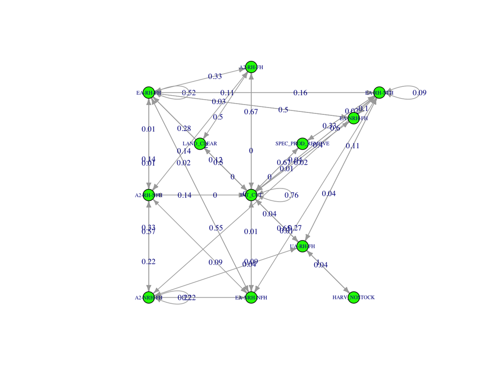

## Motivation

- Need to set up a “typical” logging sequence in southern Idaho

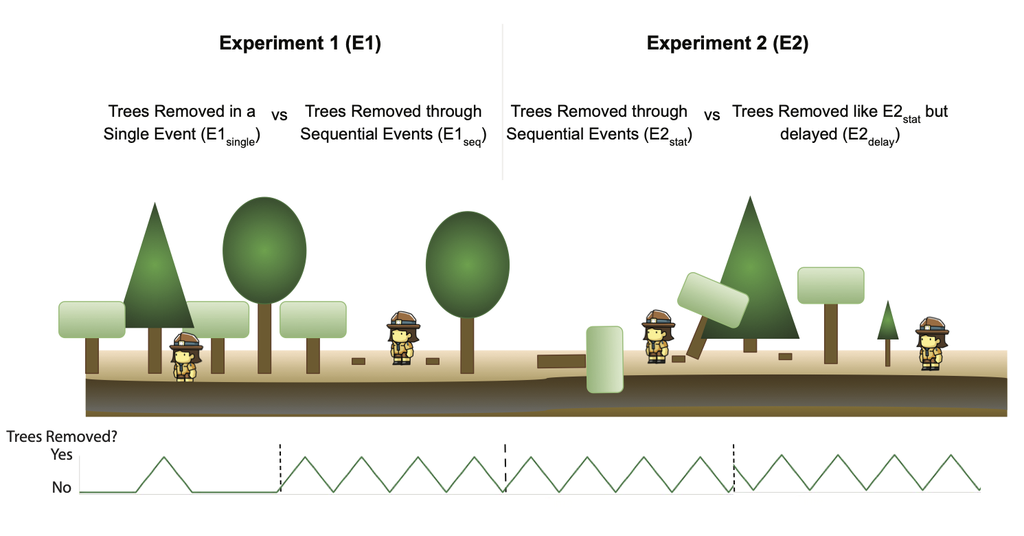

Logging Scenarios

## What is a Markov Chain?

Discrete Time Markov Chain = sequence of random variables \[X_1, X_2,...,X_n...\] Characterized by the Markov process

which is “memoryless”, the distribution of the future state \(X_{n+1}\) depends only on current state \(X_n\)

## What is a Markov Chain?

The chain moves from one step to another (i.e. the ‘transition’ or ‘step’)

State space is the set of possible states \(S = {s_1,s_2,...s_r}\). These states can be infinite or countable

Probability of \(p_{ij}\) to move from state \(s_i\) to state \(s_j\) in one step is the transition porbability

\(p_{ij} = Pr(X_1 = s_j|X_0 = s_i)\)

## What is a Markov Chain?

Distribution of transitions from one state to another represented in transition matrix

Each element of poistion \((i,j)\) represents the transtion prob \(p_{ij}\)

\[ P = \begin{bmatrix}p_{11} & p_{12} & p_{13}\\ p_{21} & p_{22} & p_{23}\\ p_{31} & p_{32} & p_{33} \end{bmatrix}\]

## The Package

There is a package in r (for everything) for Markov Chains called…markov chain.

- library(markovchain)
- library(dplyr)
- library(tidyverse)

## The Data

Load in the data. In this case the data has the following variables:

- NEPA project name
- GEN_ACTIVITY - general activity, basic definition of activity based on Forest Service objective
- Date Completed
- Acres
- SEQ_DAYS/SEQ_INT - sequence days, the number of days between activities (date/integer)
- SEQ_ACTIVITY - sequence activity, a new category, “activity to activity”

## Basic Process (I think??)

1. From data create a transition matrix
2. Fram data create a vector of states
3. Create a new Markov Chain
4. Sample Markov Chain

## Create transition matrix

```r
prob_mat <- createSequenceMatrix(df$GEN_ACTIVITY,
            toRowProbs = TRUE, sanitize = TRUE)
prob_mat
```

```
##                    A2-NRH-FH    A2-RH-FH   A2-RH-NFH  EA-NRH-FH EA-NRH-NFH
## A2-NRH-FH        0.222222222 0.000000000 0.222222222 0.00000000 0.22222222
## A2-RH-FH         0.000000000 0.000000000 0.000000000 0.00000000 0.00000000
## A2-RH-NFH        0.571428571 0.142857143 0.000000000 0.00000000 0.00000000
## EA-NRH-FH        0.000000000 0.000000000 0.000000000 0.00000000 0.00000000
## EA-NRH-NFH       0.000000000 0.000000000 0.090909091 0.00000000 0.00000000
## EA-RH-FH         0.006024096 0.000000000 0.012048193 0.03012048 0.01807229
## EA-RH-NFH        0.022222222 0.000000000 0.000000000 0.00000000 0.00000000
## HARV_NOSTOCK     0.000000000 0.000000000 0.000000000 0.00000000 0.00000000
## INT_CUT          0.000000000 0.002293578 0.004587156 0.01146789 0.01376147
## LAND_CLEAR       0.000000000 0.500000000 0.000000000 0.00000000 0.00000000
## SPEC_PROD_REMOVE 0.000000000 0.000000000 0.000000000 0.00000000 0.00000000
## UA-RH-FH         0.038461538 0.000000000 0.000000000 0.00000000 0.00000000
##                   EA-RH-FH  EA-RH-NFH HARV_NOSTOCK    INT_CUT  LAND_CLEAR
## A2-NRH-FH        0.3333333 0.00000000  0.000000000 0.00000000 0.000000000
## A2-RH-FH         0.3333333 0.00000000  0.000000000 0.66666667 0.000000000
## A2-RH-NFH        0.1428571 0.00000000  0.000000000 0.14285714 0.000000000
## EA-NRH-FH        0.5000000 0.10000000  0.000000000 0.40000000 0.000000000
## EA-NRH-NFH       0.5454545 0.27272727  0.000000000 0.09090909 0.000000000
## EA-RH-FH         0.5180723 0.10843373  0.000000000 0.28313253 0.000000000
## EA-RH-NFH        0.1555556 0.08888889  0.000000000 0.60000000 0.000000000
## HARV_NOSTOCK     0.0000000 0.00000000  0.000000000 1.00000000 0.000000000
## INT_CUT          0.1169725 0.03899083  0.006880734 0.75688073 0.004587156
## LAND_CLEAR       0.0000000 0.00000000  0.000000000 0.50000000 0.000000000
## SPEC_PROD_REMOVE 0.0000000 0.33333333  0.000000000 0.66666667 0.000000000
## UA-RH-FH         0.2307692 0.03846154  0.038461538 0.65384615 0.000000000
##                  SPEC_PROD_REMOVE   UA-RH-FH
## A2-NRH-FH             0.000000000 0.00000000
## A2-RH-FH              0.000000000 0.00000000
## A2-RH-NFH             0.000000000 0.00000000
## EA-NRH-FH             0.000000000 0.00000000
## EA-NRH-NFH            0.000000000 0.00000000
## EA-RH-FH              0.000000000 0.02409639
## EA-RH-NFH             0.022222222 0.11111111
## HARV_NOSTOCK          0.000000000 0.00000000
## INT_CUT               0.004587156 0.03899083
## LAND_CLEAR            0.000000000 0.00000000
## SPEC_PROD_REMOVE      0.000000000 0.00000000
## UA-RH-FH              0.000000000 0.00000000
```

## Create vector of states

```r
seq_states <- unique(df$GEN_ACTIVITY)
seq_states
```

```
##  [1] "INT_CUT"          "EA-RH-FH"         "UA-RH-FH"         "EA-RH-NFH"
##  [5] "A2-NRH-FH"        "EA-NRH-NFH"       "EA-NRH-FH"        "A2-RH-NFH"
##  [9] "LAND_CLEAR"       "A2-RH-FH"         "SPEC_PROD_REMOVE" "HARV_NOSTOCK"
```

## Create vector of states (put in alpha order)

```r
seq_states2 <- c("A2-NRH-FH", "A2-RH-FH", "A2-RH-NFH", "EA-NRH-FH", "EA-NRH-NFH", "EA-RH-FH", "EA-RH-NFH", "HARV_NOSTOCK", "INT_CUT", "LAND_CLEAR", "SPEC_PROD_REMOVE", "UA-RH-FH")
seq_states2
```

```
##  [1] "A2-NRH-FH"        "A2-RH-FH"         "A2-RH-NFH"        "EA-NRH-FH"
##  [5] "EA-NRH-NFH"       "EA-RH-FH"         "EA-RH-NFH"        "HARV_NOSTOCK"
##  [9] "INT_CUT"          "LAND_CLEAR"       "SPEC_PROD_REMOVE" "UA-RH-FH"
```

## Create a new Markov Chain

```r
mc_tmp <- new("markovchain",
                states = seq_states2,
                transitionMatrix = prob_mat)

mc <- as(mc_tmp, "data.frame")
print(head(mc))
```

```
##          t0         t1      prob
## 1 A2-NRH-FH  A2-NRH-FH 0.2222222
## 2 A2-NRH-FH   A2-RH-FH 0.0000000
## 3 A2-NRH-FH  A2-RH-NFH 0.2222222
## 4 A2-NRH-FH  EA-NRH-FH 0.0000000
## 5 A2-NRH-FH EA-NRH-NFH 0.2222222
## 6 A2-NRH-FH   EA-RH-FH 0.3333333
```

## Can sample from Markov Chain

```r
seq_sim <- rmarkovchain(5, mc_tmp, "data.frame", t0 = "INT_CUT")
seq_sim
```

```
## [1] "EA-NRH-NFH" "INT_CUT"    "INT_CUT"    "EA-RH-NFH"  "UA-RH-FH"
```

## Can repeat many times? Any common patterns?

```r
seq_sims <- replicate(20, {
  sequence <- rmarkovchain(5, mc_tmp, "data.frame", t0 = "INT_CUT")
})
seq_sims
```

```
##      [,1]       [,2]       [,3]        [,4]      [,5]      [,6]
## [1,] "EA-RH-FH" "EA-RH-FH" "INT_CUT"   "INT_CUT" "INT_CUT" "INT_CUT"
## [2,] "EA-RH-FH" "INT_CUT"  "INT_CUT"   "INT_CUT" "INT_CUT" "INT_CUT"
## [3,] "INT_CUT"  "INT_CUT"  "INT_CUT"   "INT_CUT" "INT_CUT" "UA-RH-FH"
## [4,] "EA-RH-FH" "INT_CUT"  "INT_CUT"   "INT_CUT" "INT_CUT" "INT_CUT"
## [5,] "EA-RH-FH" "INT_CUT"  "EA-RH-NFH" "INT_CUT" "INT_CUT" "INT_CUT"
##      [,7]        [,8]       [,9]        [,10]        [,11]      [,12]
## [1,] "UA-RH-FH"  "INT_CUT"  "EA-RH-FH"  "INT_CUT"    "EA-RH-FH" "INT_CUT"
## [2,] "INT_CUT"   "INT_CUT"  "EA-NRH-FH" "INT_CUT"    "EA-RH-FH" "INT_CUT"
## [3,] "INT_CUT"   "INT_CUT"  "EA-RH-FH"  "INT_CUT"    "INT_CUT"  "EA-RH-NFH"
## [4,] "EA-RH-NFH" "EA-RH-FH" "EA-RH-FH"  "EA-NRH-NFH" "INT_CUT"  "INT_CUT"
## [5,] "INT_CUT"   "INT_CUT"  "EA-RH-FH"  "EA-RH-FH"   "INT_CUT"  "INT_CUT"
##      [,13]          [,14]     [,15]     [,16]       [,17]     [,18]
## [1,] "INT_CUT"      "INT_CUT" "INT_CUT" "EA-RH-FH"  "INT_CUT" "EA-RH-FH"
## [2,] "INT_CUT"      "INT_CUT" "INT_CUT" "EA-RH-NFH" "INT_CUT" "EA-RH-FH"
## [3,] "HARV_NOSTOCK" "INT_CUT" "INT_CUT" "EA-RH-FH"  "INT_CUT" "EA-RH-FH"
## [4,] "INT_CUT"      "INT_CUT" "INT_CUT" "EA-RH-NFH" "INT_CUT" "EA-RH-FH"
## [5,] "INT_CUT"      "INT_CUT" "INT_CUT" "INT_CUT"   "INT_CUT" "EA-RH-FH"
##      [,19]       [,20]
## [1,] "EA-RH-FH"  "INT_CUT"
## [2,] "EA-RH-FH"  "INT_CUT"
## [3,] "INT_CUT"   "INT_CUT"
## [4,] "EA-RH-NFH" "INT_CUT"
## [5,] "INT_CUT"   "INT_CUT"
```

## Moving Forward

- Still don’t fully understand “under the hood”
- Still don’t understand time and timing
  - really to to know the transition times from one state (activity) to another

## I Moved Forward

- Created a couple new datasets
  - 1 with National Forests for S. Idaho
  - 1 with National Forests for larger regions (includes NFs in WY, OR, MT)
- Most importantly:
  - these datasets now have a row for every day of a project
  - these datasets contain a column for action (1) - no action (0)
- Got a lot of practice with functions in Python to streamline process

## New Chains

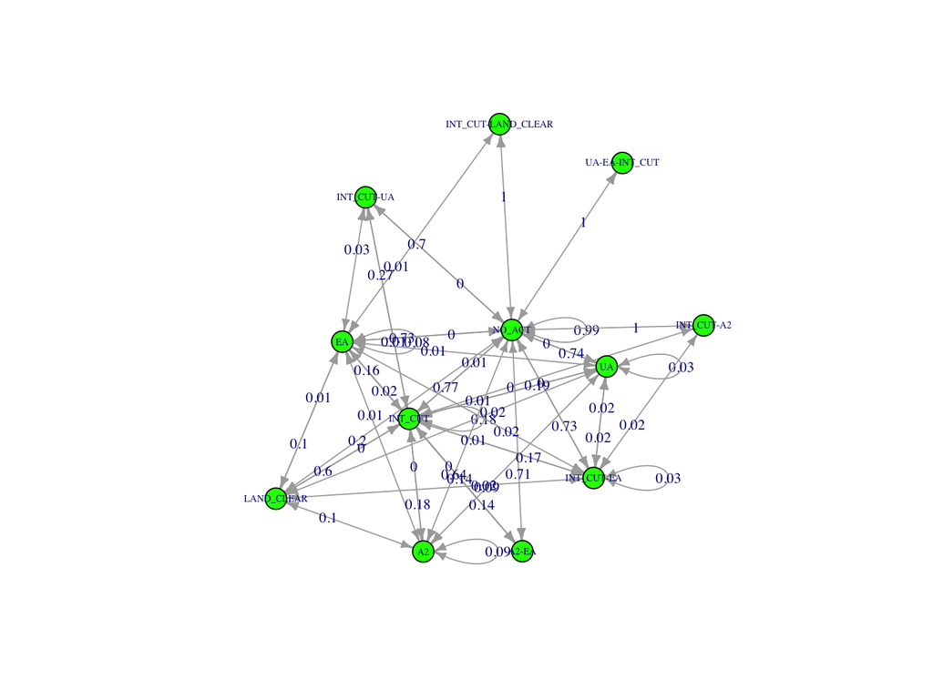

## New Chains

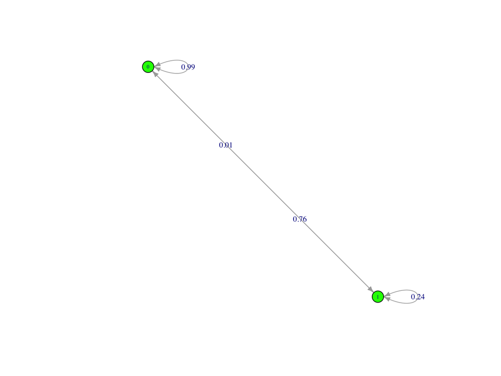

## New Chains

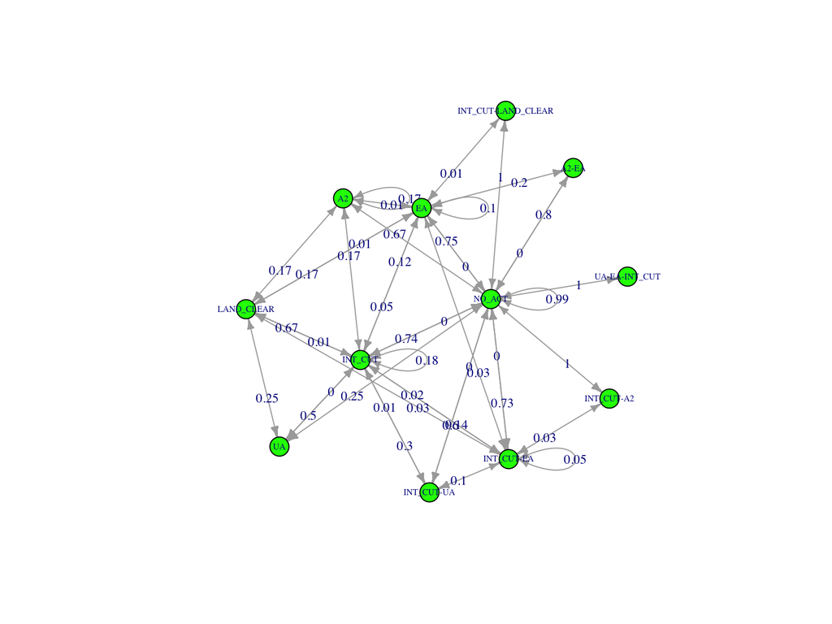

## New Chains

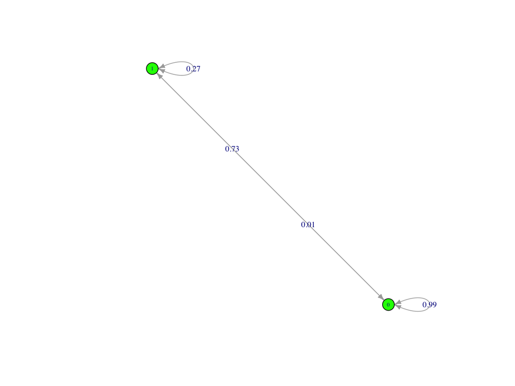

## Mean First Passage of Time

Super easy to do.

```r
#Dataset with SIdaho NFs.
meanFirstPassageTime(markov7.1)
```

## Mean First Passage of Time

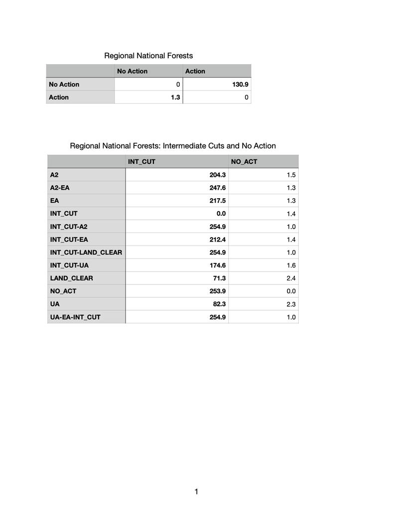

## Mean First Passage of Time

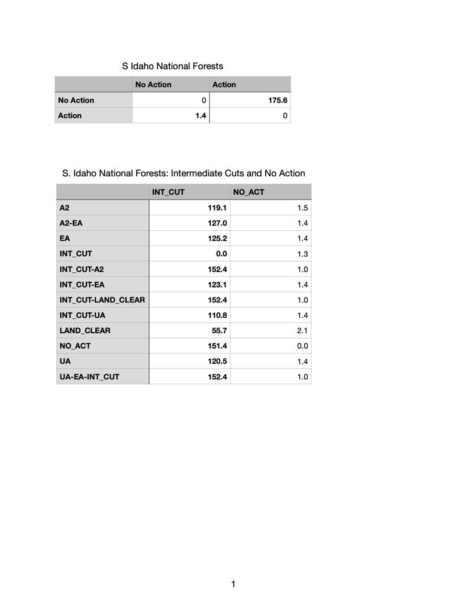